# corona_Switzerland

Thakshila Nanayakkara

20/07/2020

# Packages need to install

```r
library(coronavirus)
library(tidyverse)
library(magrittr)
library(ggplot2)
library(maptools)
library(tibble)
library(tidyverse)
library(ggrepel)
library(png)
library(grid)
library(sp)
library(knitr)
library(skimr)
```

$$1.About\ Switzerland$$

*Introduction

Switzerland belongs to the european continent which is boundered by Swiss Apls to the south, Swiss Plateu and Jura mountins on the west.

*Climatic Condition

Switzerland faced all the climates: Spring, Summer, Autumn and Winter in different quartiles of the year. from July to August the daytime temperature is 18°to 28°C and from January to February it goes to -2° to 7°C.

```r
data("coronavirus")
head(coronavirus)
```

```
        date province     country lat long      type cases
1 2020-01-22          Afghanistan  33   65 confirmed     0
2 2020-01-23          Afghanistan  33   65 confirmed     0
3 2020-01-24          Afghanistan  33   65 confirmed     0
4 2020-01-25          Afghanistan  33   65 confirmed     0
5 2020-01-26          Afghanistan  33   65 confirmed     0
6 2020-01-27          Afghanistan  33   65 confirmed     0
```

```r
tail(coronavirus)
```

```
            date province country     lat     long      type cases
87803 2020-05-07 Zhejiang   China 29.1832 120.0934 recovered     0
87804 2020-05-08 Zhejiang   China 29.1832 120.0934 recovered     0
87805 2020-05-09 Zhejiang   China 29.1832 120.0934 recovered     0
87806 2020-05-10 Zhejiang   China 29.1832 120.0934 recovered     0
87807 2020-05-11 Zhejiang   China 29.1832 120.0934 recovered     0
87808 2020-05-12 Zhejiang   China 29.1832 120.0934 recovered     0
```

```r
glimpse(coronavirus)
```

```
Rows: 87,808
Columns: 7
$ date     <date> 2020-01-22, 2020-01-23, 2020-01-24, 2020-01-25, 2020-01-2...
$ province <chr> "", "", "", "", "", "", "", "", "", "", "", "", "", "", ""...
$ country  <chr> "Afghanistan", "Afghanistan", "Afghanistan", "Afghanistan"...
$ lat      <dbl> 33, 33, 33, 33, 33, 33, 33, 33, 33, 33, 33, 33, 33, 33, 33...
$ long     <dbl> 65, 65, 65, 65, 65, 65, 65, 65, 65, 65, 65, 65, 65, 65, 65...
$ type     <chr> "confirmed", "confirmed", "confirmed", "confirmed", "confi...
$ cases    <int> 0, 0, 0, 0, 0, 0, 0, 0, 0, 0, 0, 0, 0, 0, 0, 0, 0, 0, 0, 0...
```

```r
unique(coronavirus$country)
```

```
  [1] "Afghanistan"                      "Albania"
  [3] "Algeria"                          "Andorra"
  [5] "Angola"                           "Antigua and Barbuda"
  [7] "Argentina"                        "Armenia"
  [9] "Austria"                          "Azerbaijan"
 [11] "Bahamas"                          "Bahrain"
 [13] "Bangladesh"                       "Barbados"
 [15] "Belarus"                          "Belgium"
 [17] "Belize"                           "Benin"
 [19] "Bhutan"                           "Bolivia"
 [21] "Bosnia and Herzegovina"           "Botswana"
 [23] "Brazil"                           "Brunei"
 [25] "Bulgaria"                         "Burkina Faso"
 [27] "Burma"                            "Burundi"
 [29] "Cabo Verde"                       "Cambodia"
```

[output cut: 79 more lines]

## Corona dataset in Switzerland

```r
switz_corona <- coronavirus %>% filter(country == "Switzerland")
switz_corona
```

```
          date province     country     lat   long      type cases
1   2020-01-22          Switzerland 46.8182 8.2275 confirmed     0
2   2020-01-23          Switzerland 46.8182 8.2275 confirmed     0
3   2020-01-24          Switzerland 46.8182 8.2275 confirmed     0
4   2020-01-25          Switzerland 46.8182 8.2275 confirmed     0
5   2020-01-26          Switzerland 46.8182 8.2275 confirmed     0
6   2020-01-27          Switzerland 46.8182 8.2275 confirmed     0
7   2020-01-28          Switzerland 46.8182 8.2275 confirmed     0
8   2020-01-29          Switzerland 46.8182 8.2275 confirmed     0
9   2020-01-30          Switzerland 46.8182 8.2275 confirmed     0
10  2020-01-31          Switzerland 46.8182 8.2275 confirmed     0
11  2020-02-01          Switzerland 46.8182 8.2275 confirmed     0
12  2020-02-02          Switzerland 46.8182 8.2275 confirmed     0
13  2020-02-03          Switzerland 46.8182 8.2275 confirmed     0
14  2020-02-04          Switzerland 46.8182 8.2275 confirmed     0
```

[output cut: 322 more lines]

### recovered cases at first & last days

```r
recover_switz_corona <- switz_corona %>% filter(type == "recovered")
head(recover_switz_corona)
```

```
        date province     country     lat   long      type cases
1 2020-01-22          Switzerland 46.8182 8.2275 recovered     0
2 2020-01-23          Switzerland 46.8182 8.2275 recovered     0
3 2020-01-24          Switzerland 46.8182 8.2275 recovered     0
4 2020-01-25          Switzerland 46.8182 8.2275 recovered     0
5 2020-01-26          Switzerland 46.8182 8.2275 recovered     0
6 2020-01-27          Switzerland 46.8182 8.2275 recovered     0
```

```r
tail(recover_switz_corona)
```

```
          date province     country     lat   long      type cases
107 2020-05-07          Switzerland 46.8182 8.2275 recovered   200
108 2020-05-08          Switzerland 46.8182 8.2275 recovered   200
109 2020-05-09          Switzerland 46.8182 8.2275 recovered   300
110 2020-05-10          Switzerland 46.8182 8.2275 recovered   200
111 2020-05-11          Switzerland 46.8182 8.2275 recovered   200
112 2020-05-12          Switzerland 46.8182 8.2275 recovered     0
```

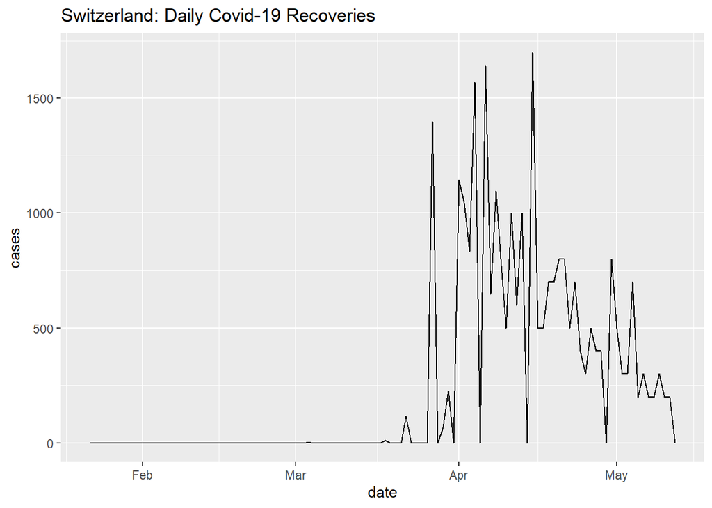

```r
ggplot(recover_switz_corona, aes(x=date, y=cases)) + geom_line() + ggtitle("Switzerland: Daily Covid-19 Recoveries")
```

*Visualisation of Switzerland

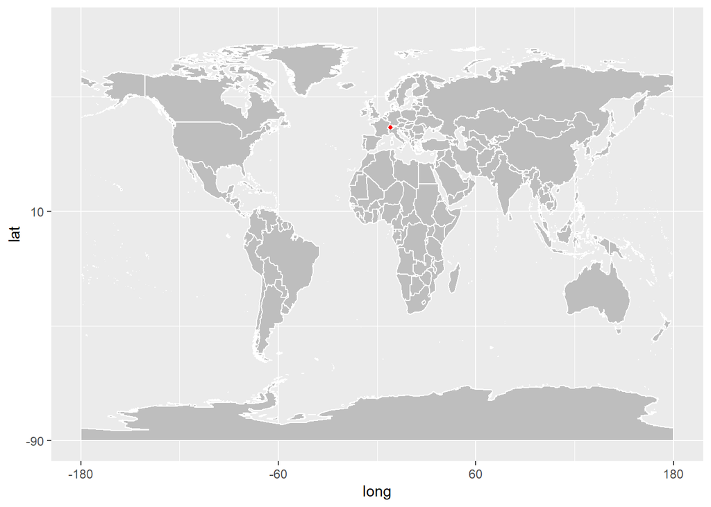

```r
data(wrld_simpl)

p <- ggplot() +
  geom_polygon(
    data = wrld_simpl,
    aes(x = long, y = lat, group = group), fill = "gray", colour = "white") +
  coord_cartesian(xlim = c(-180, 180), ylim = c(-90, 90)) +
  scale_x_continuous(breaks = seq(-180, 180, 120)) +
  scale_y_continuous(breaks = seq(-90, 90, 100))

p +
  geom_point(
    data = switz_corona, aes(x = long, y = lat), color = "red", size
    = 1
  )
```

*Lockdown status of Switzerland

The virus was confirmed have spread to Switzerland on 25th of February, 2020.the first case of COVID-19 was confirmed from the canton of Ticino which borders Italy. On 28th February, 2020 the national government banned all the events with more than 1,000 participants. On 16 March, after confirmed cases are over 2,000, schools and most shops were closed. On 20 March, all gatherings of more than 5 people in public spacces were banned.

```r
world_recovered <- coronavirus %>%
  filter(type == 'recovered') %>%
  group_by(country) %>%
  filter(cases == max(cases)) %>%
  arrange(desc(date))
```

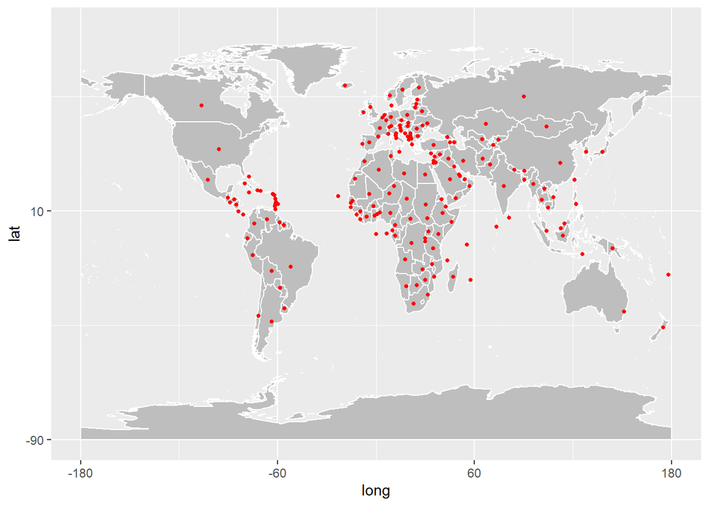

```r
data(wrld_simpl)

p <- ggplot() +
  geom_polygon(
    data = wrld_simpl,
    aes(x = long, y = lat, group = group), fill = "gray", colour = "white") +
  coord_cartesian(xlim = c(-180, 180), ylim = c(-90, 90)) +
  scale_x_continuous(breaks = seq(-180, 180, 120)) +
  scale_y_continuous(breaks = seq(-90, 90, 100))

p +
  geom_point(
    data = world_recovered, aes(x = long, y = lat), color = "red", size
    = 1
  )
```

```r
switz_type <- switz_corona %>% group_by(type)
switz_type
```

```
# A tibble: 336 x 7
# Groups:   type [3]
   date       province country       lat  long type      cases
   <date>     <chr>    <chr>       <dbl> <dbl> <chr>     <int>
 1 2020-01-22 ""       Switzerland  46.8  8.23 confirmed     0
 2 2020-01-23 ""       Switzerland  46.8  8.23 confirmed     0
 3 2020-01-24 ""       Switzerland  46.8  8.23 confirmed     0
 4 2020-01-25 ""       Switzerland  46.8  8.23 confirmed     0
 5 2020-01-26 ""       Switzerland  46.8  8.23 confirmed     0
 6 2020-01-27 ""       Switzerland  46.8  8.23 confirmed     0
 7 2020-01-28 ""       Switzerland  46.8  8.23 confirmed     0
 8 2020-01-29 ""       Switzerland  46.8  8.23 confirmed     0
 9 2020-01-30 ""       Switzerland  46.8  8.23 confirmed     0
10 2020-01-31 ""       Switzerland  46.8  8.23 confirmed     0
# ... with 326 more rows
```

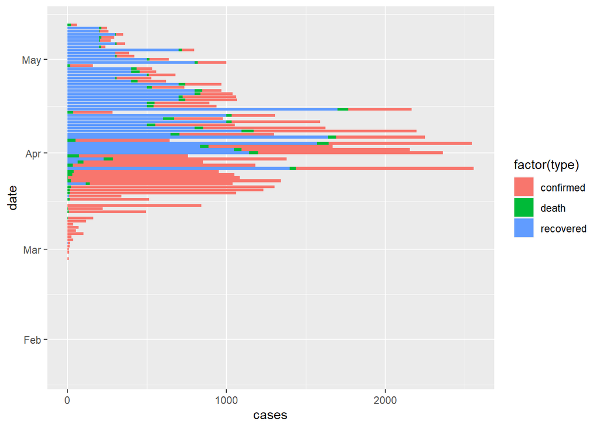

```r
ggplot(switz_corona, aes(x=date, y=cases,fill=factor(type))) + geom_bar(position="stack", stat="identity") + coord_flip()
```

The above barchart shows that mostly in march and april more corona cases were found.

**All the corona cases in Switzerland**

```r
pivot_switz_type <- switz_type %>%
pivot_wider(c(1, 4:7), names_from = "type", values_from = "cases")
kable(pivot_switz_type)
```

| date | lat | long | confirmed | death | recovered |
| --- | --- | --- | --- | --- | --- |
| 2020-01-22 | 46.8182 | 8.2275 | 0 | 0 | 0 |
| 2020-01-23 | 46.8182 | 8.2275 | 0 | 0 | 0 |
| 2020-01-24 | 46.8182 | 8.2275 | 0 | 0 | 0 |
| 2020-01-25 | 46.8182 | 8.2275 | 0 | 0 | 0 |
| 2020-01-26 | 46.8182 | 8.2275 | 0 | 0 | 0 |
| 2020-01-27 | 46.8182 | 8.2275 | 0 | 0 | 0 |
| 2020-01-28 | 46.8182 | 8.2275 | 0 | 0 | 0 |
| 2020-01-29 | 46.8182 | 8.2275 | 0 | 0 | 0 |
| 2020-01-30 | 46.8182 | 8.2275 | 0 | 0 | 0 |
| 2020-01-31 | 46.8182 | 8.2275 | 0 | 0 | 0 |
| 2020-02-01 | 46.8182 | 8.2275 | 0 | 0 | 0 |
| 2020-02-02 | 46.8182 | 8.2275 | 0 | 0 | 0 |
| 2020-02-03 | 46.8182 | 8.2275 | 0 | 0 | 0 |
| 2020-02-04 | 46.8182 | 8.2275 | 0 | 0 | 0 |
| 2020-02-05 | 46.8182 | 8.2275 | 0 | 0 | 0 |
| 2020-02-06 | 46.8182 | 8.2275 | 0 | 0 | 0 |
| 2020-02-07 | 46.8182 | 8.2275 | 0 | 0 | 0 |
| 2020-02-08 | 46.8182 | 8.2275 | 0 | 0 | 0 |
| 2020-02-09 | 46.8182 | 8.2275 | 0 | 0 | 0 |
| 2020-02-10 | 46.8182 | 8.2275 | 0 | 0 | 0 |
| 2020-02-11 | 46.8182 | 8.2275 | 0 | 0 | 0 |
| 2020-02-12 | 46.8182 | 8.2275 | 0 | 0 | 0 |
| 2020-02-13 | 46.8182 | 8.2275 | 0 | 0 | 0 |
| 2020-02-14 | 46.8182 | 8.2275 | 0 | 0 | 0 |
| 2020-02-15 | 46.8182 | 8.2275 | 0 | 0 | 0 |
| 2020-02-16 | 46.8182 | 8.2275 | 0 | 0 | 0 |
| 2020-02-17 | 46.8182 | 8.2275 | 0 | 0 | 0 |
| 2020-02-18 | 46.8182 | 8.2275 | 0 | 0 | 0 |
| 2020-02-19 | 46.8182 | 8.2275 | 0 | 0 | 0 |
| 2020-02-20 | 46.8182 | 8.2275 | 0 | 0 | 0 |

[output cut: 82 more lines]

```r
switz_corona_cases <- select(pivot_switz_type, c(date, lat, long, confirmed, death, recovered))
switz_corona_cases
```

```
# A tibble: 112 x 6
   date         lat  long confirmed death recovered
   <date>     <dbl> <dbl>     <int> <int>     <int>
 1 2020-01-22  46.8  8.23         0     0         0
 2 2020-01-23  46.8  8.23         0     0         0
 3 2020-01-24  46.8  8.23         0     0         0
 4 2020-01-25  46.8  8.23         0     0         0
 5 2020-01-26  46.8  8.23         0     0         0
 6 2020-01-27  46.8  8.23         0     0         0
 7 2020-01-28  46.8  8.23         0     0         0
 8 2020-01-29  46.8  8.23         0     0         0
 9 2020-01-30  46.8  8.23         0     0         0
10 2020-01-31  46.8  8.23         0     0         0
# ... with 102 more rows
```

```r
summary(switz_corona_cases)
```

```
      date                 lat             long         confirmed
 Min.   :2020-01-22   Min.   :46.82   Min.   :8.227   Min.   :   0.0
 1st Qu.:2020-02-18   1st Qu.:46.82   1st Qu.:8.227   1st Qu.:   0.0
 Median :2020-03-17   Median :46.82   Median :8.227   Median :  72.5
 Mean   :2020-03-17   Mean   :46.82   Mean   :8.227   Mean   : 271.2
 3rd Qu.:2020-04-14   3rd Qu.:46.82   3rd Qu.:8.227   3rd Qu.: 397.0
 Max.   :2020-05-12   Max.   :46.82   Max.   :8.227   Max.   :1321.0
     death         recovered
 Min.   : 0.00   Min.   :   0.0
 1st Qu.: 0.00   1st Qu.:   0.0
 Median : 2.00   Median :   0.0
 Mean   :16.67   Mean   : 239.3
 3rd Qu.:33.25   3rd Qu.: 400.0
 Max.   :75.00   Max.   :1700.0
```

1. Confirmed corona cases in Switzerland

```r
switz_confirmed_corona <- select(switz_corona_cases, c(date,confirmed))
summary(switz_confirmed_corona)
```

```
      date              confirmed
 Min.   :2020-01-22   Min.   :   0.0
 1st Qu.:2020-02-18   1st Qu.:   0.0
 Median :2020-03-17   Median :  72.5
 Mean   :2020-03-17   Mean   : 271.2
 3rd Qu.:2020-04-14   3rd Qu.: 397.0
 Max.   :2020-05-12   Max.   :1321.0
```

```r
arrange(switz_confirmed_corona, desc(confirmed))
```

```
# A tibble: 112 x 2
   date       confirmed
   <date>         <int>
 1 2020-03-23      1321
 2 2020-03-21      1281
 3 2020-03-20      1219
 4 2020-04-01      1163
 5 2020-03-28      1148
 6 2020-03-27      1117
 7 2020-03-30      1093
 8 2020-03-24      1082
 9 2020-04-02      1059
10 2020-03-19      1047
# ... with 102 more rows
```

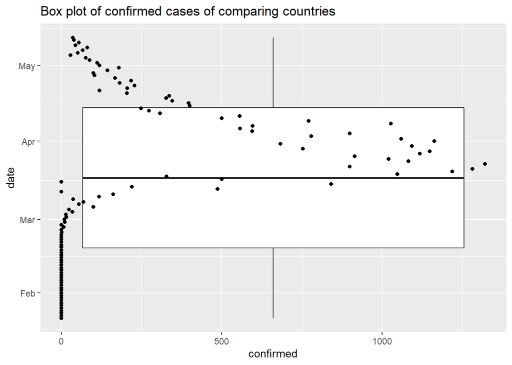

```r
#plot to represent the data
ggplot(switz_confirmed_corona,
       aes(x = confirmed, y = date)) +
  geom_boxplot() +
  geom_point() +
  labs(title = "Box plot of confirmed cases of comparing countries")
```

The above descriptive statistics and box plot show that at the last weeks of March and first week of April, more corona patients were confirmed.

2. Deaths due to corona virus in Switzerland

```r
switz_death_corona <- select(switz_corona_cases, c(date,death))
summary(switz_death_corona)
```

```
      date                death
 Min.   :2020-01-22   Min.   : 0.00
 1st Qu.:2020-02-18   1st Qu.: 0.00
 Median :2020-03-17   Median : 2.00
 Mean   :2020-03-17   Mean   :16.67
 3rd Qu.:2020-04-14   3rd Qu.:33.25
 Max.   :2020-05-12   Max.   :75.00
```

```r
arrange(switz_death_corona, desc(death))
```

```
# A tibble: 112 x 2
   date       death
   <date>     <int>
 1 2020-04-04    75
 2 2020-03-31    74
 3 2020-04-08    74
 4 2020-04-12    70
 5 2020-04-15    65
 6 2020-03-30    59
 7 2020-04-07    56
 8 2020-04-01    55
 9 2020-04-03    55
10 2020-04-27    55
# ... with 102 more rows
```

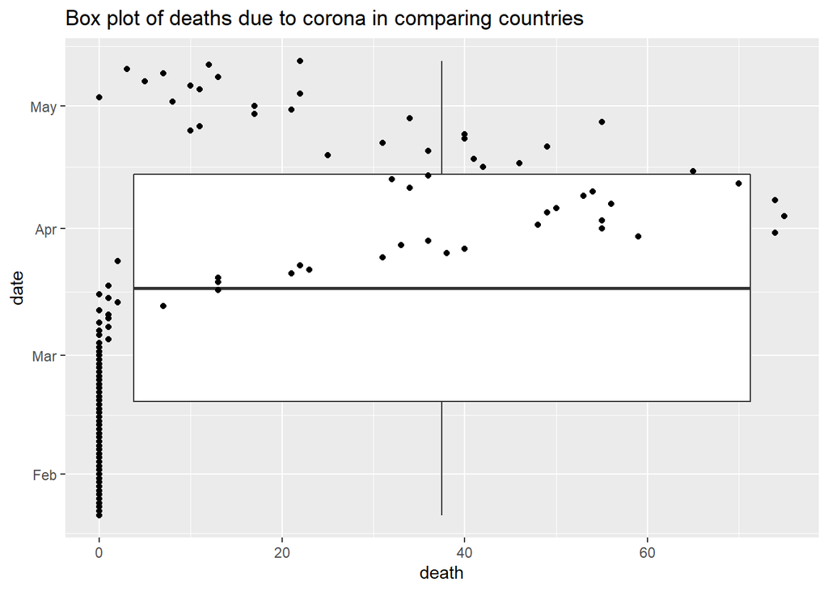

```r
#plot to represent the data
ggplot(switz_death_corona,
       aes(x = death, y = date)) +
  geom_boxplot() +
  geom_point() +
  labs(title = "Box plot of deaths due to corona in comparing countries")
```

The above data figured that at the first weeks of April many patients with coronavirus got died.

3. Recovered corona cases in Switzerland

```r
switz_recovered_corona <- select(switz_corona_cases, c(date,recovered))
summary(switz_recovered_corona)
```

```
      date              recovered
 Min.   :2020-01-22   Min.   :   0.0
 1st Qu.:2020-02-18   1st Qu.:   0.0
 Median :2020-03-17   Median :   0.0
 Mean   :2020-03-17   Mean   : 239.3
 3rd Qu.:2020-04-14   3rd Qu.: 400.0
 Max.   :2020-05-12   Max.   :1700.0
```

```r
arrange(switz_recovered_corona, desc(recovered))
```

```
# A tibble: 112 x 2
   date       recovered
   <date>         <int>
 1 2020-04-15      1700
 2 2020-04-06      1641
 3 2020-04-04      1569
 4 2020-03-27      1399
 5 2020-04-01      1144
 6 2020-04-08      1096
 7 2020-04-02      1046
 8 2020-04-11      1000
 9 2020-04-13      1000
10 2020-04-03       833
# ... with 102 more rows
```

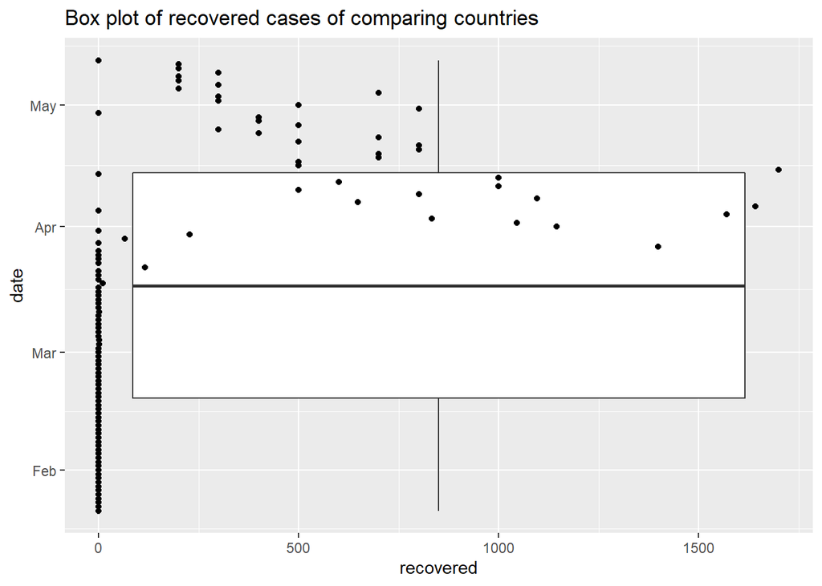

```r
#plot to represent the data
ggplot(switz_recovered_corona,
       aes(x = recovered, y = date)) +
  geom_boxplot() +
  geom_point() +
  labs(title = "Box plot of recovered cases of comparing countries")
```

The begining of the month of April, more corona cases were recovered and the mean of recovered cases is 239.3 per day.

$$Comparison \ With\ Other\ Countries$$

```r
pivot_corona <- coronavirus %>%
pivot_wider(c(1:7), names_from = "type", values_from = "cases")
```

```r
compare_corona <- coronavirus %>% filter(country == c("Switzerland", "China", "US", "United Kingdom", "France", "Germany"))
```

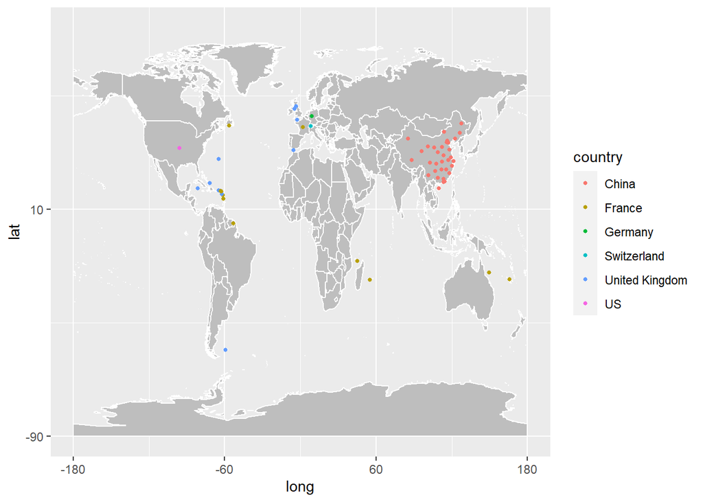

```r
data("wrld_simpl")

p <- ggplot() +
  geom_polygon(
    data = wrld_simpl,
    aes(x = long, y = lat, group = group), fill = "grey", colour = "white"
  ) +
  coord_cartesian(xlim = c(-180, 180), ylim = c(-90, 90)) +
  scale_x_continuous(breaks = seq(-180, 180, 120)) +
  scale_y_continuous(breaks = seq(-90, 90, 100))

p +
  geom_point(
    data = compare_corona, aes(x = long, y = lat, col = country), size
    = 1
  )
```

```r
pivot_compare_corona <- compare_corona %>%
pivot_wider(c(1:7), names_from = "type", values_from = "cases")
```

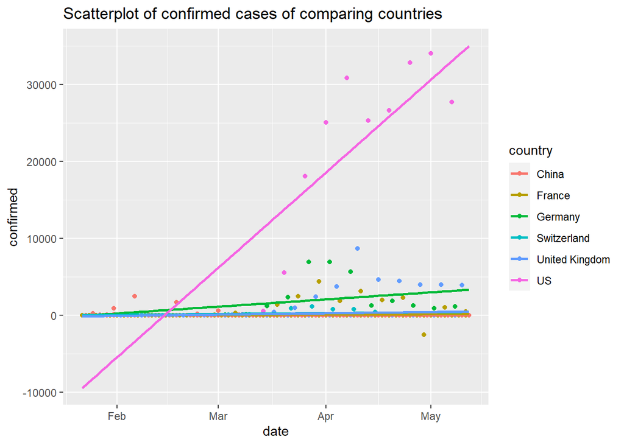

```r
ggplot(pivot_compare_corona,
       aes(x = date, y = confirmed, col = country)) +
  geom_point() +
  geom_smooth(method = lm, se = F, fullrange = T) +
  labs(title = "Scatterplot of confirmed cases of comparing countries")
```

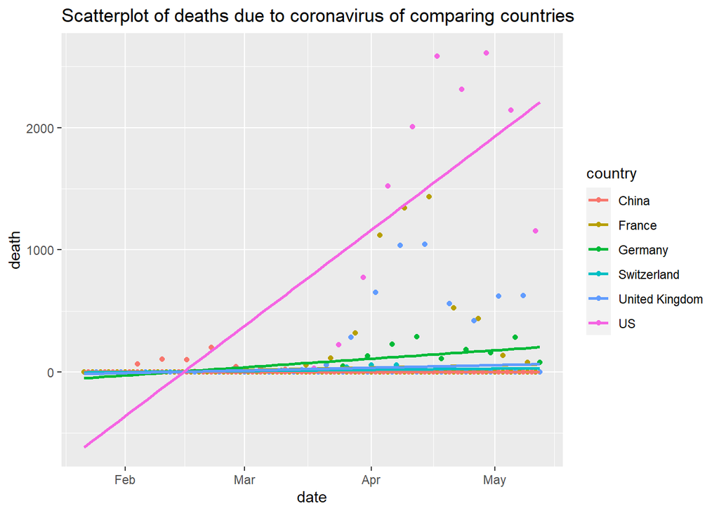

```r
ggplot(pivot_compare_corona,
       aes(x = date, y = death, col = country)) +
  geom_point() +
  geom_smooth(method = lm, se = F, fullrange = T) +
  labs(title = "Scatterplot of deaths due to coronavirus of comparing countries")
```

Here also same as the scaterplot of confirmed cases of comparing countries. United States shows a greater slope and Switzerland has an insignificant linear regression.

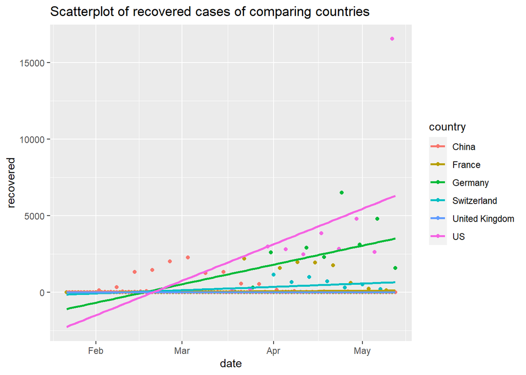

```r
ggplot(pivot_compare_corona,
       aes(x = date, y = recovered, col = country)) +
  geom_point() +
  geom_smooth(method = lm, se = F, fullrange = T) +
  labs(title = "Scatterplot of recovered cases of comparing countries")
```

The above scatterplot represents United Staes, Germany and Switzerland have greater increments of recovered cases respectively.

$$3.\ Conclusion$$

$$4. \ References$$

https://hellor.netlify.app/resources/

https://r4ds.had.co.nz/exploratory-data-analysis.html

https://r4ds.had.co.nz/data-visualisation.html

https://classroom.google.com/w/NjIwMTA0MDIzMTJa/t/all

https://en.wikipedia.org/wiki/Switzerland

https://www.myswitzerland.com/en/planning/about-switzerland/general-facts/facts-about-switzerland/climate/#:~:text=The%20climate%20is%20moderate%20with,%C2%B0%20%2D%2059%C2%B0%20F).

https://en.wikipedia.org/wiki/COVID-19_pandemic_in_Switzerland